# Forest Cover Type

Groupe : BOMBARD Thierry, DIALLO Ibrahima, MARC Jordan

```python
import pandas as pd
import numpy as np
import matplotlib.pyplot as plt
import seaborn as sns
```

## Présentation des données

Le jeu de données Forest Cover Type provient de plusieurs sources :

- Remote Sensing and GIS Program
- Department of Forest Sciences
- College of Natural Resources
- Colorado State University
- Fort Collins, CO 80523

La récolte de ces données a été effectuée dans 4 différentes zones sauvages situées dans la forêt nationale Roosevelt (dans une parcelle de 30x30 mètres chacunes), au nord du Colorado. Ces zones représentent des forêts avec des perturbations anthropiques minimales, de telles sorte que les types de couvert forestier soient à priori le résultat d'un processus écologique plutôt que de pratiques de gestions forestières. Ces données traitent donc la caractérisation de plusieurs types de couvert forestier, selon une panoplie d'éléments cartographiques.

Définitions :

- Un couvert forestier désigne l'ensemble formé par les cimes des arbres d'une forêt.
- Une perturbation anthropique est une perturbation écologique causée par l'Homme.

Nous avons listé les 7 différents types de couverts forestiers avec pour chaucun de ces types leurs correspondances numériques renseignés dans notre jeu de données :

```
    Spruce/Fir (1)
    Lodgepole Pine (2)
    Ponderosa Pine (3)
    Cottonwood/Willow (4)
    Aspen (5)
    Douglas-fir (6)
    Krummholz (7)
```

Notre dataset initial contient 15120 observations pour un total de 56 attributs. Toutes les données sont numériques et il n'existe aucune valeur manquante.

Significations des attributs :

```
    'Elevation' : élévation en mètres.
    'Aspect' : l'aspect en degrés azimuts.
    'Slope' : pente en degrés.
    'Horizontal_Distance_To_Hydrology' : distance horizontale à la surface d'eau la plus proche.
    'Vertical_Distance_To_Hydrology' : distance verticale à la surface d'eau la plus proche.
    'Horizontal_Distance_To_Roadways' : distance horizontale à la chaussée la plus proche.
    'Hillshade_9am' (indice allant de 0 à 255) : indice d'ombre portée à 9h au solstice d'été.
    'Hillshade_Noon' (indice allant de 0 à 255) : indice d'ombre portée à midi, au solstice d'été.
    'Hillshade_3pm' (indice allant de 0 à 255) : indice d'ombre portée à 15h, au solstice d'été.
    'Horizontal_Distance_To_Fire_Points' : distance horizontale au point de départ du feu de forêt le plus proche.
    'Wilderness_Area1' (variable binaire, 0 = absence, 1 = présence) : zone sauvage Rawah.
    'Wilderness_Area2' (variable binaire, 0 = absence, 1 = présence) : zone sauvage Neota.
    'Wilderness_Area3' (variable binaire, 0 = absence, 1 = présence) : zone sauvage Comanche Peak.
    'Wilderness_Area4' (variable binaire, 0 = absence, 1 = présence) : zone sauvage Cache la Poudre.
    'Soil_Type1 (jusqu'à Soil_Type40, variable binaire, 0 = absence, 1 = présence) : types de sols.
    'Cover_Type' (valeurs numériques allant de 1 à 7) : couverts forestiers.
```

Liste des différents types de sols :

```
    1 Famille de la cathédrale - Complexe d’affleurements rocheux, extrêmement pierreux.
    2 Vanet - Complexe familial Ratake, très pierreux.
    3 Haploborolis - Complexe d’affleurements rocheux.
    4 Famille Ratake - Complexe d’affleurements rocheux.
    5 Famille Vanet - Complexe complexe d’affleurements rocheux.
    6 Vanet - Familles Wetmore - Complexe d’affleurements rocheux, pierreux.
    7 Famille gothique.
    8 Superviseur - Complexe de familles souples.
    9 Famille Troutville, très pierreuse.
    10 Bullwark - Familles Catamount - Complexe d’affleurements rocheux.
    11 Bullwark - Familles Catamount - Complexe rocheux, rocailleux.
    12 Famille Legault - Complexe rocheux, pierreux.
    13 Famille Catamount - Rock land - Complexe familial Bullwark, en ruines.
    14 Argiborolis pachic - Complexe Aquolis.
    15 non spécifié dans l’enquête USFS Soil and ELU.
    16 Cryaquolis - Complexe cryoborolique.
    17 Famille Gateview - Cryaquolis
    18 Famille Rogert, très pierreuse.
    19 Cryaquolis typique - Complexe borohémiste.
    20 Typic Cryaquepts - Typic Cryaquolls complex.
    21 Cryaquolls typiques - Famille Leighcan, complexe de substrat de till.
    22 Famille Leighcan, substrat de till, fort semblable à un bloc.
    23 Famille Leighcan, substrat de till - Complexe typique de Cryaquolls.
    24 Famille Leighcan, extrêmement pierreuse.
    25 Famille Leighcan, chaude, extrêmement pierreuse.
    26 Granile - Complexe familial Catamount, très pierreux.
    27 Famille Leighcan, chaud - Complexe d’affleurements rocheux, extrêmement pierreux.
    28 Famille Leighcan - Complexe d’affleurements rocheux, extrêmement pierreux.
    29 Como - Complexe familial Legault, extrêmement pierreux.
    30 Famille Como - Rocher - Complexe familial Legault, extrêmement pierreux.
    31 Leighcan - Catamount familles complexe, extrêmement pierreux.
    32 Famille Catamount - Affleurement rocheux - Complexe familial Leighcan
    33 Leighcan - Familles Catamount - Complexe d’affleurements rocheux, extrêmement pierreux.
    34 Cryorthents - Complexe rocheux, extrêmement pierreux.
    35 Cryumbrepts - Affleurement rocheux - Complexe Cryaquepts.
    36 Famille Bross - Terrain rocheux - Complexe Cryumbrepts, extrêmement pierreux.
    37 Affleurement rocheux - Cryumbrepts - Complexe de cryorthents, extrêmement pierreux.
    38 Leighcan - Familles Moran - Complexe de Cryaquolls, extrêmement pierreux.
    39 Famille Moran - Cryorthents - Complexe familial Leighcan, extrêmement pierreux.
    40 Famille Moran - Cryorthents - Complexe rocheux, extrêmement pierreux.
```

```python
df = pd.read_csv('train.csv')
df
```

|  | Id | Elevation | Aspect | Slope | Horizontal_Distance_To_Hydrology | Vertical_Distance_To_Hydrology | Horizontal_Distance_To_Roadways | Hillshade_9am | Hillshade_Noon | Hillshade_3pm | ... | Soil_Type32 | Soil_Type33 | Soil_Type34 | Soil_Type35 | Soil_Type36 | Soil_Type37 | Soil_Type38 | Soil_Type39 | Soil_Type40 | Cover_Type |
| --- | --- | --- | --- | --- | --- | --- | --- | --- | --- | --- | --- | --- | --- | --- | --- | --- | --- | --- | --- | --- | --- |
| 0 | 1 | 2596 | 51 | 3 | 258 | 0 | 510 | 221 | 232 | 148 | ... | 0 | 0 | 0 | 0 | 0 | 0 | 0 | 0 | 0 | 5 |
| 1 | 2 | 2590 | 56 | 2 | 212 | -6 | 390 | 220 | 235 | 151 | ... | 0 | 0 | 0 | 0 | 0 | 0 | 0 | 0 | 0 | 5 |
| 2 | 3 | 2804 | 139 | 9 | 268 | 65 | 3180 | 234 | 238 | 135 | ... | 0 | 0 | 0 | 0 | 0 | 0 | 0 | 0 | 0 | 2 |
| 3 | 4 | 2785 | 155 | 18 | 242 | 118 | 3090 | 238 | 238 | 122 | ... | 0 | 0 | 0 | 0 | 0 | 0 | 0 | 0 | 0 | 2 |
| 4 | 5 | 2595 | 45 | 2 | 153 | -1 | 391 | 220 | 234 | 150 | ... | 0 | 0 | 0 | 0 | 0 | 0 | 0 | 0 | 0 | 5 |
| ... | ... | ... | ... | ... | ... | ... | ... | ... | ... | ... | ... | ... | ... | ... | ... | ... | ... | ... | ... | ... | ... |
| 15115 | 15116 | 2607 | 243 | 23 | 258 | 7 | 660 | 170 | 251 | 214 | ... | 0 | 0 | 0 | 0 | 0 | 0 | 0 | 0 | 0 | 3 |
| 15116 | 15117 | 2603 | 121 | 19 | 633 | 195 | 618 | 249 | 221 | 91 | ... | 0 | 0 | 0 | 0 | 0 | 0 | 0 | 0 | 0 | 3 |
| 15117 | 15118 | 2492 | 134 | 25 | 365 | 117 | 335 | 250 | 220 | 83 | ... | 0 | 0 | 0 | 0 | 0 | 0 | 0 | 0 | 0 | 3 |
| 15118 | 15119 | 2487 | 167 | 28 | 218 | 101 | 242 | 229 | 237 | 119 | ... | 0 | 0 | 0 | 0 | 0 | 0 | 0 | 0 | 0 | 3 |
| 15119 | 15120 | 2475 | 197 | 34 | 319 | 78 | 270 | 189 | 244 | 164 | ... | 0 | 0 | 0 | 0 | 0 | 0 | 0 | 0 | 0 | 3 |

15120 rows × 56 columns

## Quelques manipulations avec pandas et numpy

```python
# Extraction du jeu de donnés en csv
df.to_csv('df_csv.csv', encoding='utf-8')
```

```python
# Trier par ordre décroissant les valeurs d'Elevation
df.sort_values(by='Elevation', ascending=False)
```

|  | Id | Elevation | Aspect | Slope | Horizontal_Distance_To_Hydrology | Vertical_Distance_To_Hydrology | Horizontal_Distance_To_Roadways | Hillshade_9am | Hillshade_Noon | Hillshade_3pm | ... | Soil_Type32 | Soil_Type33 | Soil_Type34 | Soil_Type35 | Soil_Type36 | Soil_Type37 | Soil_Type38 | Soil_Type39 | Soil_Type40 | Cover_Type |
| --- | --- | --- | --- | --- | --- | --- | --- | --- | --- | --- | --- | --- | --- | --- | --- | --- | --- | --- | --- | --- | --- |
| 9727 | 9728 | 3849 | 353 | 9 | 984 | 73 | 4592 | 204 | 224 | 158 | ... | 0 | 0 | 0 | 0 | 0 | 0 | 0 | 0 | 1 | 7 |
| 14562 | 14563 | 3849 | 348 | 17 | 891 | 73 | 4444 | 186 | 209 | 160 | ... | 0 | 0 | 0 | 0 | 0 | 0 | 0 | 0 | 1 | 7 |
| 9726 | 9727 | 3848 | 353 | 8 | 1008 | 72 | 4622 | 207 | 227 | 158 | ... | 0 | 0 | 0 | 0 | 0 | 0 | 0 | 0 | 1 | 7 |
| 9723 | 9724 | 3846 | 342 | 1 | 949 | 397 | 4743 | 217 | 237 | 157 | ... | 0 | 0 | 0 | 0 | 0 | 0 | 0 | 0 | 1 | 7 |
| 9724 | 9725 | 3846 | 15 | 3 | 973 | 397 | 4713 | 217 | 233 | 154 | ... | 0 | 0 | 0 | 0 | 0 | 0 | 0 | 0 | 1 | 7 |
| ... | ... | ... | ... | ... | ... | ... | ... | ... | ... | ... | ... | ... | ... | ... | ... | ... | ... | ... | ... | ... | ... |
| 2186 | 2187 | 1889 | 353 | 30 | 95 | 39 | 67 | 153 | 172 | 146 | ... | 0 | 0 | 0 | 0 | 0 | 0 | 0 | 0 | 0 | 6 |
| 2233 | 2234 | 1888 | 33 | 22 | 150 | 46 | 108 | 209 | 185 | 103 | ... | 0 | 0 | 0 | 0 | 0 | 0 | 0 | 0 | 0 | 6 |
| 2214 | 2215 | 1879 | 28 | 19 | 30 | 12 | 95 | 209 | 196 | 117 | ... | 0 | 0 | 0 | 0 | 0 | 0 | 0 | 0 | 0 | 6 |
| 2215 | 2216 | 1874 | 18 | 14 | 0 | 0 | 90 | 208 | 209 | 135 | ... | 0 | 0 | 0 | 0 | 0 | 0 | 0 | 0 | 0 | 6 |
| 2234 | 2235 | 1863 | 37 | 17 | 120 | 18 | 90 | 217 | 202 | 115 | ... | 0 | 0 | 0 | 0 | 0 | 0 | 0 | 0 | 0 | 6 |

15120 rows × 56 columns

```python
# La somme des pentes par zone sauvage 1, indexé par les types de couverts forestiers.
table1 = pd.pivot_table(df, values='Slope', index=['Cover_Type'],
                    columns=['Wilderness_Area1'], aggfunc=np.sum)
table1
```

| Wilderness_Area1 Cover_Type | 0 | 1 |
| --- | --- | --- |
| 1 | 15066.0 | 13258.0 |
| 2 | 15650.0 | 13345.0 |
| 3 | 44558.0 | NaN |
| 4 | 39892.0 | NaN |
| 5 | 19088.0 | 17037.0 |
| 6 | 41010.0 | NaN |
| 7 | 23201.0 | 7399.0 |

```python
table1.isna() # Pour détecter les valeurs manquantes pour chaque valeur de la zone sauvage 1
```

| Wilderness_Area1 Cover_Type | 0 | 1 |
| --- | --- | --- |
| 1 | False | False |
| 2 | False | False |
| 3 | False | True |
| 4 | False | True |
| 5 | False | False |
| 6 | False | True |
| 7 | False | False |

```python
# Génération de nombre allant de 3 à 33 avec un pas de 2
np.arange(3, 33, 2)
```

```
array([ 3,  5,  7,  9, 11, 13, 15, 17, 19, 21, 23, 25, 27, 29, 31])
```

```python
# Utilisation de pd.where
arange1 = pd.Series(np.arange(3, 33, 2))
arange1.where(arange1 > 10)
```

```
0      NaN
1      NaN
2      NaN
3      NaN
4     11.0
5     13.0
6     15.0
7     17.0
8     19.0
9     21.0
10    23.0
11    25.0
12    27.0
13    29.0
14    31.0
dtype: float64
```

```python
# Utilisation de sample pour extraire certains éléments du dataframe, avec un seed de 1
sample1 = df['Slope'].sample(n=3, random_state=1)
sample1
```

```
5765     18
11340    13
9270     17
Name: Slope, dtype: int64
```

```python
# Sélection des lignes qui contiennent '77' avec filter
df.filter(like='77', axis=0)
```

|  | Id | Elevation | Aspect | Slope | Horizontal_Distance_To_Hydrology | Vertical_Distance_To_Hydrology | Horizontal_Distance_To_Roadways | Hillshade_9am | Hillshade_Noon | Hillshade_3pm | ... | Soil_Type32 | Soil_Type33 | Soil_Type34 | Soil_Type35 | Soil_Type36 | Soil_Type37 | Soil_Type38 | Soil_Type39 | Soil_Type40 | Cover_Type |
| --- | --- | --- | --- | --- | --- | --- | --- | --- | --- | --- | --- | --- | --- | --- | --- | --- | --- | --- | --- | --- | --- |
| 77 | 78 | 2529 | 326 | 5 | 30 | 14 | 1062 | 207 | 234 | 166 | ... | 0 | 0 | 0 | 0 | 0 | 0 | 0 | 0 | 0 | 2 |
| 177 | 178 | 2955 | 288 | 21 | 247 | 128 | 5224 | 156 | 233 | 215 | ... | 0 | 0 | 0 | 0 | 0 | 0 | 0 | 0 | 0 | 2 |
| 277 | 278 | 2789 | 320 | 15 | 182 | 50 | 1771 | 181 | 225 | 183 | ... | 0 | 0 | 0 | 0 | 0 | 0 | 0 | 0 | 0 | 2 |
| 377 | 378 | 2844 | 317 | 10 | 67 | 20 | 2758 | 194 | 231 | 178 | ... | 0 | 0 | 0 | 0 | 0 | 0 | 0 | 0 | 0 | 2 |
| 477 | 478 | 3001 | 267 | 14 | 641 | 101 | 5749 | 182 | 245 | 201 | ... | 0 | 0 | 0 | 0 | 0 | 0 | 0 | 0 | 0 | 2 |
| ... | ... | ... | ... | ... | ... | ... | ... | ... | ... | ... | ... | ... | ... | ... | ... | ... | ... | ... | ... | ... | ... |
| 14778 | 14779 | 3350 | 49 | 19 | 95 | 26 | 1298 | 224 | 196 | 99 | ... | 0 | 0 | 0 | 0 | 0 | 0 | 1 | 0 | 0 | 7 |
| 14779 | 14780 | 3397 | 332 | 38 | 277 | 144 | 990 | 107 | 164 | 180 | ... | 0 | 0 | 0 | 0 | 0 | 0 | 0 | 1 | 0 | 7 |
| 14877 | 14878 | 2580 | 142 | 6 | 85 | 2 | 892 | 229 | 239 | 143 | ... | 0 | 0 | 0 | 0 | 0 | 0 | 0 | 0 | 0 | 3 |
| 14977 | 14978 | 2446 | 66 | 21 | 242 | 49 | 582 | 235 | 192 | 78 | ... | 0 | 0 | 0 | 0 | 0 | 0 | 0 | 0 | 0 | 6 |
| 15077 | 15078 | 2524 | 34 | 22 | 30 | 4 | 1550 | 211 | 186 | 102 | ... | 0 | 0 | 0 | 0 | 0 | 0 | 0 | 0 | 0 | 3 |

376 rows × 56 columns

```python
# Nous pouvons utiliser aussi filter pour sélectionner que certaines colonnes de notre dataframe
df.filter(items=['Elevation', 'Aspect'])
```

|  | Elevation | Aspect |
| --- | --- | --- |
| 0 | 2596 | 51 |
| 1 | 2590 | 56 |
| 2 | 2804 | 139 |
| 3 | 2785 | 155 |
| 4 | 2595 | 45 |
| ... | ... | ... |
| 15115 | 2607 | 243 |
| 15116 | 2603 | 121 |
| 15117 | 2492 | 134 |
| 15118 | 2487 | 167 |
| 15119 | 2475 | 197 |

15120 rows × 2 columns

## Exploration des données

```python
df.dtypes # toutes les valeurs sont numériques
```

```
Id                                    int64
Elevation                             int64
Aspect                                int64
Slope                                 int64
Horizontal_Distance_To_Hydrology      int64
Vertical_Distance_To_Hydrology        int64
Horizontal_Distance_To_Roadways       int64
Hillshade_9am                         int64
Hillshade_Noon                        int64
Hillshade_3pm                         int64
Horizontal_Distance_To_Fire_Points    int64
Wilderness_Area1                      int64
Wilderness_Area2                      int64
Wilderness_Area3                      int64
Wilderness_Area4                      int64
Soil_Type1                            int64
Soil_Type2                            int64
Soil_Type3                            int64
Soil_Type4                            int64
Soil_Type5                            int64
Soil_Type6                            int64
Soil_Type7                            int64
Soil_Type8                            int64
Soil_Type9                            int64
Soil_Type10                           int64
Soil_Type11                           int64
Soil_Type12                           int64
Soil_Type13                           int64
Soil_Type14                           int64
Soil_Type15                           int64
Soil_Type16                           int64
Soil_Type17                           int64
Soil_Type18                           int64
Soil_Type19                           int64
Soil_Type20                           int64
Soil_Type21                           int64
Soil_Type22                           int64
Soil_Type23                           int64
Soil_Type24                           int64
Soil_Type25                           int64
Soil_Type26                           int64
Soil_Type27                           int64
Soil_Type28                           int64
Soil_Type29                           int64
Soil_Type30                           int64
Soil_Type31                           int64
Soil_Type32                           int64
Soil_Type33                           int64
Soil_Type34                           int64
Soil_Type35                           int64
Soil_Type36                           int64
Soil_Type37                           int64
Soil_Type38                           int64
Soil_Type39                           int64
Soil_Type40                           int64
Cover_Type                            int64
dtype: object
```

```python
pd.set_option('display.max_columns', None) # pour voir l'ensemble des colonnes
df.describe()
```

|  | Id | Elevation | Aspect | Slope | Horizontal_Distance_To_Hydrology | Vertical_Distance_To_Hydrology | Horizontal_Distance_To_Roadways | Hillshade_9am | Hillshade_Noon | Hillshade_3pm | Horizontal_Distance_To_Fire_Points | Wilderness_Area1 | Wilderness_Area2 | Wilderness_Area3 | Wilderness_Area4 | Soil_Type1 | Soil_Type2 | Soil_Type3 | Soil_Type4 | Soil_Type5 | Soil_Type6 | Soil_Type7 | Soil_Type8 | Soil_Type9 | Soil_Type10 | Soil_Type11 | Soil_Type12 | Soil_Type13 | Soil_Type14 | … |
| --- | --- | --- | --- | --- | --- | --- | --- | --- | --- | --- | --- | --- | --- | --- | --- | --- | --- | --- | --- | --- | --- | --- | --- | --- | --- | --- | --- | --- | --- | --- |
| count | 15120.00000 | 15120.000000 | 15120.000000 | 15120.000000 | 15120.000000 | 15120.000000 | 15120.000000 | 15120.000000 | 15120.000000 | 15120.000000 | 15120.000000 | 15120.000000 | 15120.000000 | 15120.000000 | 15120.000000 | 15120.000000 | 15120.000000 | 15120.000000 | 15120.000000 | 15120.000000 | 15120.000000 | 15120.0 | 15120.000000 | 15120.000000 | 15120.000000 | 15120.000000 | 15120.000000 | 15120.000000 | 15120.000000 | … |
| mean | 7560.50000 | 2749.322553 | 156.676653 | 16.501587 | 227.195701 | 51.076521 | 1714.023214 | 212.704299 | 218.965608 | 135.091997 | 1511.147288 | 0.237897 | 0.033003 | 0.419907 | 0.309193 | 0.023479 | 0.041204 | 0.063624 | 0.055754 | 0.010913 | 0.042989 | 0.0 | 0.000066 | 0.000661 | 0.141667 | 0.026852 | 0.015013 | 0.031481 | 0.011177 | … |
| std | 4364.91237 | 417.678187 | 110.085801 | 8.453927 | 210.075296 | 61.239406 | 1325.066358 | 30.561287 | 22.801966 | 45.895189 | 1099.936493 | 0.425810 | 0.178649 | 0.493560 | 0.462176 | 0.151424 | 0.198768 | 0.244091 | 0.229454 | 0.103896 | 0.202840 | 0.0 | 0.008133 | 0.025710 | 0.348719 | 0.161656 | 0.121609 | 0.174621 | 0.105133 | … |
| min | 1.00000 | 1863.000000 | 0.000000 | 0.000000 | 0.000000 | -146.000000 | 0.000000 | 0.000000 | 99.000000 | 0.000000 | 0.000000 | 0.000000 | 0.000000 | 0.000000 | 0.000000 | 0.000000 | 0.000000 | 0.000000 | 0.000000 | 0.000000 | 0.000000 | 0.0 | 0.000000 | 0.000000 | 0.000000 | 0.000000 | 0.000000 | 0.000000 | 0.000000 | … |
| 25% | 3780.75000 | 2376.000000 | 65.000000 | 10.000000 | 67.000000 | 5.000000 | 764.000000 | 196.000000 | 207.000000 | 106.000000 | 730.000000 | 0.000000 | 0.000000 | 0.000000 | 0.000000 | 0.000000 | 0.000000 | 0.000000 | 0.000000 | 0.000000 | 0.000000 | 0.0 | 0.000000 | 0.000000 | 0.000000 | 0.000000 | 0.000000 | 0.000000 | 0.000000 | … |
| 50% | 7560.50000 | 2752.000000 | 126.000000 | 15.000000 | 180.000000 | 32.000000 | 1316.000000 | 220.000000 | 223.000000 | 138.000000 | 1256.000000 | 0.000000 | 0.000000 | 0.000000 | 0.000000 | 0.000000 | 0.000000 | 0.000000 | 0.000000 | 0.000000 | 0.000000 | 0.0 | 0.000000 | 0.000000 | 0.000000 | 0.000000 | 0.000000 | 0.000000 | 0.000000 | … |
| 75% | 11340.25000 | 3104.000000 | 261.000000 | 22.000000 | 330.000000 | 79.000000 | 2270.000000 | 235.000000 | 235.000000 | 167.000000 | 1988.250000 | 0.000000 | 0.000000 | 1.000000 | 1.000000 | 0.000000 | 0.000000 | 0.000000 | 0.000000 | 0.000000 | 0.000000 | 0.0 | 0.000000 | 0.000000 | 0.000000 | 0.000000 | 0.000000 | 0.000000 | 0.000000 | … |
| max | 15120.00000 | 3849.000000 | 360.000000 | 52.000000 | 1343.000000 | 554.000000 | 6890.000000 | 254.000000 | 254.000000 | 248.000000 | 6993.000000 | 1.000000 | 1.000000 | 1.000000 | 1.000000 | 1.000000 | 1.000000 | 1.000000 | 1.000000 | 1.000000 | 1.000000 | 0.0 | 1.000000 | 1.000000 | 1.000000 | 1.000000 | 1.000000 | 1.000000 | 1.000000 | … |

Soil_Type7 et Soil_Type15 sont des colonnes remplies de 0. La colonne Id ne nous est pas utile étant donné que nous utilisons l'indexation de pandas.

```python
df = df.drop(['Id', 'Soil_Type7', 'Soil_Type15'], axis = 1) # suppression des colonnes Id, Soil_Type7 et Soil_Type15
```

```python
df["Cover_Type"].unique()
```

```
array([5, 2, 1, 7, 3, 6, 4], dtype=int64)
```

## Valeurs nulles

```python
# Comptage des valeurs nulles/manquantes par colonnes
df.isnull().sum() # df.isna().sum() fonctionne aussi
```

```
Elevation                             0
Aspect                                0
Slope                                 0
Horizontal_Distance_To_Hydrology      0
Vertical_Distance_To_Hydrology        0
Horizontal_Distance_To_Roadways       0
Hillshade_9am                         0
Hillshade_Noon                        0
Hillshade_3pm                         0
Horizontal_Distance_To_Fire_Points    0
Wilderness_Area1                      0
Wilderness_Area2                      0
Wilderness_Area3                      0
Wilderness_Area4                      0
Soil_Type1                            0
Soil_Type2                            0
Soil_Type3                            0
Soil_Type4                            0
Soil_Type5                            0
Soil_Type6                            0
Soil_Type8                            0
Soil_Type9                            0
Soil_Type10                           0
Soil_Type11                           0
Soil_Type12                           0
Soil_Type13                           0
Soil_Type14                           0
Soil_Type16                           0
Soil_Type17                           0
Soil_Type18                           0
Soil_Type19                           0
Soil_Type20                           0
Soil_Type21                           0
Soil_Type22                           0
Soil_Type23                           0
Soil_Type24                           0
Soil_Type25                           0
Soil_Type26                           0
Soil_Type27                           0
Soil_Type28                           0
Soil_Type29                           0
Soil_Type30                           0
Soil_Type31                           0
Soil_Type32                           0
Soil_Type33                           0
Soil_Type34                           0
Soil_Type35                           0
Soil_Type36                           0
Soil_Type37                           0
Soil_Type38                           0
Soil_Type39                           0
Soil_Type40                           0
Cover_Type                            0
dtype: int64
```

## Equilibre de la variable à prédire

```python
df.loc[:,['Cover_Type', 'Elevation', 'Aspect', 'Slope', 'Horizontal_Distance_To_Hydrology',
       'Vertical_Distance_To_Hydrology', 'Horizontal_Distance_To_Roadways',
       'Hillshade_9am', 'Hillshade_Noon', 'Hillshade_3pm',
       'Horizontal_Distance_To_Fire_Points', 'Wilderness_Area1',
       'Wilderness_Area2', 'Wilderness_Area3', 'Wilderness_Area4',
       'Soil_Type1', 'Soil_Type2', 'Soil_Type3', 'Soil_Type4', 'Soil_Type5',
       'Soil_Type6', 'Soil_Type8', 'Soil_Type9', 'Soil_Type10', 'Soil_Type11',
       'Soil_Type12', 'Soil_Type13', 'Soil_Type14', 'Soil_Type16',
       'Soil_Type17', 'Soil_Type18', 'Soil_Type19', 'Soil_Type20',
       'Soil_Type21', 'Soil_Type22', 'Soil_Type23', 'Soil_Type24',
       'Soil_Type25', 'Soil_Type26', 'Soil_Type27', 'Soil_Type28',
       'Soil_Type29', 'Soil_Type30', 'Soil_Type31', 'Soil_Type32',
       'Soil_Type33', 'Soil_Type34', 'Soil_Type35', 'Soil_Type36',
       'Soil_Type37', 'Soil_Type38', 'Soil_Type39', 'Soil_Type40']].groupby(by='Cover_Type').count()
```

| Cover_Type | Elevation | Aspect | Slope | Horizontal_Distance_To_Hydrology | Vertical_Distance_To_Hydrology | Horizontal_Distance_To_Roadways | Hillshade_9am | Hillshade_Noon | Hillshade_3pm | Horizontal_Distance_To_Fire_Points | Wilderness_Area1 | Wilderness_Area2 | Wilderness_Area3 | Wilderness_Area4 | Soil_Type1 | Soil_Type2 | Soil_Type3 | Soil_Type4 | Soil_Type5 | Soil_Type6 | Soil_Type8 | Soil_Type9 | Soil_Type10 | Soil_Type11 | Soil_Type12 | Soil_Type13 | Soil_Type14 | Soil_Type16 | Soil_Type17 | … |
| --- | --- | --- | --- | --- | --- | --- | --- | --- | --- | --- | --- | --- | --- | --- | --- | --- | --- | --- | --- | --- | --- | --- | --- | --- | --- | --- | --- | --- | --- | --- |
| 1 | 2160 | 2160 | 2160 | 2160 | 2160 | 2160 | 2160 | 2160 | 2160 | 2160 | 2160 | 2160 | 2160 | 2160 | 2160 | 2160 | 2160 | 2160 | 2160 | 2160 | 2160 | 2160 | 2160 | 2160 | 2160 | 2160 | 2160 | 2160 | 2160 | … |
| 2 | 2160 | 2160 | 2160 | 2160 | 2160 | 2160 | 2160 | 2160 | 2160 | 2160 | 2160 | 2160 | 2160 | 2160 | 2160 | 2160 | 2160 | 2160 | 2160 | 2160 | 2160 | 2160 | 2160 | 2160 | 2160 | 2160 | 2160 | 2160 | 2160 | … |
| 3 | 2160 | 2160 | 2160 | 2160 | 2160 | 2160 | 2160 | 2160 | 2160 | 2160 | 2160 | 2160 | 2160 | 2160 | 2160 | 2160 | 2160 | 2160 | 2160 | 2160 | 2160 | 2160 | 2160 | 2160 | 2160 | 2160 | 2160 | 2160 | 2160 | … |
| 4 | 2160 | 2160 | 2160 | 2160 | 2160 | 2160 | 2160 | 2160 | 2160 | 2160 | 2160 | 2160 | 2160 | 2160 | 2160 | 2160 | 2160 | 2160 | 2160 | 2160 | 2160 | 2160 | 2160 | 2160 | 2160 | 2160 | 2160 | 2160 | 2160 | … |
| 5 | 2160 | 2160 | 2160 | 2160 | 2160 | 2160 | 2160 | 2160 | 2160 | 2160 | 2160 | 2160 | 2160 | 2160 | 2160 | 2160 | 2160 | 2160 | 2160 | 2160 | 2160 | 2160 | 2160 | 2160 | 2160 | 2160 | 2160 | 2160 | 2160 | … |
| 6 | 2160 | 2160 | 2160 | 2160 | 2160 | 2160 | 2160 | 2160 | 2160 | 2160 | 2160 | 2160 | 2160 | 2160 | 2160 | 2160 | 2160 | 2160 | 2160 | 2160 | 2160 | 2160 | 2160 | 2160 | 2160 | 2160 | 2160 | 2160 | 2160 | … |
| 7 | 2160 | 2160 | 2160 | 2160 | 2160 | 2160 | 2160 | 2160 | 2160 | 2160 | 2160 | 2160 | 2160 | 2160 | 2160 | 2160 | 2160 | 2160 | 2160 | 2160 | 2160 | 2160 | 2160 | 2160 | 2160 | 2160 | 2160 | 2160 | 2160 | … |

Le nombre de couverts forestiers (variable à prédire) est équilibré. Pour chaque type nous avons 2160 lignes dans notre dataset.

## Coefficients d'asymétrie

```python
# Lorsque le coefficient est nul, la distribution est symétrique
# Lorsque le coefficient est négatif, la distribution est décalée vers la droite et étalée vers la gauche
# Lorsque le coefficient est positif, la distribution est décalée vers la gauche et étalée vers la droite

df.skew()
```

```
Elevation                               0.075640
Aspect                                  0.450935
Slope                                   0.523658
Horizontal_Distance_To_Hydrology        1.488052
Vertical_Distance_To_Hydrology          1.537776
Horizontal_Distance_To_Roadways         1.247811
Hillshade_9am                          -1.093681
Hillshade_Noon                         -0.953232
Hillshade_3pm                          -0.340827
Horizontal_Distance_To_Fire_Points      1.617099
Wilderness_Area1                        1.231244
Wilderness_Area2                        5.228781
Wilderness_Area3                        0.324594
Wilderness_Area4                        0.825798
Soil_Type1                              6.294716
Soil_Type2                              4.617019
Soil_Type3                              3.575995
Soil_Type4                              3.872721
Soil_Type5                              9.416209
Soil_Type6                              4.506716
Soil_Type8                            122.963409
Soil_Type9                             38.849712
Soil_Type10                             2.055410
Soil_Type11                             5.854551
Soil_Type12                             7.977205
Soil_Type13                             5.366836
Soil_Type14                             9.300318
Soil_Type16                            11.387050
Soil_Type17                             4.663945
Soil_Type18                            15.781426
Soil_Type19                            18.048915
Soil_Type20                            10.286265
Soil_Type21                            30.695081
Soil_Type22                             6.391991
Soil_Type23                             4.126701
Soil_Type24                             7.474026
Soil_Type25                           122.963409
Soil_Type26                            16.645076
Soil_Type27                            31.704896
Soil_Type28                            40.955261
Soil_Type29                             2.967651
Soil_Type30                             4.231913
Soil_Type31                             6.524804
Soil_Type32                             4.354839
Soil_Type33                             4.646742
Soil_Type34                            26.161230
Soil_Type35                            12.052838
Soil_Type36                            38.849712
Soil_Type37                            21.018939
Soil_Type38                             4.221771
Soil_Type39                             4.479186
Soil_Type40                             5.475256
Cover_Type                              0.000000
dtype: float64
```

## Matrice des corrélations

Etat de nos corrélations :

```python
# Nous avons selectionné toutes nos variables quantitatives. On n'utilise pas les variables qui sont catégorielles et de type 0 et 1.
df.iloc[:,0:10].corr()
```

|  | Elevation | Aspect | Slope | Horizontal_Distance_To_Hydrology | Vertical_Distance_To_Hydrology | Horizontal_Distance_To_Roadways | Hillshade_9am | Hillshade_Noon | Hillshade_3pm | Horizontal_Distance_To_Fire_Points |
| --- | --- | --- | --- | --- | --- | --- | --- | --- | --- | --- |
| Elevation | 1.000000 | -0.011096 | -0.312640 | 0.412712 | 0.122092 | 0.578659 | 0.097900 | 0.215782 | 0.089518 | 0.443563 |
| Aspect | -0.011096 | 1.000000 | 0.028148 | 0.040732 | 0.056412 | 0.066184 | -0.593997 | 0.324912 | 0.635022 | -0.052169 |
| Slope | -0.312640 | 0.028148 | 1.000000 | -0.055976 | 0.265314 | -0.277049 | -0.200072 | -0.612613 | -0.326887 | -0.239527 |
| Horizontal_Distance_To_Hydrology | 0.412712 | 0.040732 | -0.055976 | 1.000000 | 0.652142 | 0.203397 | -0.033803 | 0.080047 | 0.080833 | 0.158817 |
| Vertical_Distance_To_Hydrology | 0.122092 | 0.056412 | 0.265314 | 0.652142 | 1.000000 | 0.011555 | -0.095930 | -0.132948 | -0.035559 | -0.015048 |
| Horizontal_Distance_To_Roadways | 0.578659 | 0.066184 | -0.277049 | 0.203397 | 0.011555 | 1.000000 | -0.003398 | 0.240684 | 0.173882 | 0.486386 |
| Hillshade_9am | 0.097900 | -0.593997 | -0.200072 | -0.033803 | -0.095930 | -0.003398 | 1.000000 | -0.013712 | -0.779965 | 0.078144 |
| Hillshade_Noon | 0.215782 | 0.324912 | -0.612613 | 0.080047 | -0.132948 | 0.240684 | -0.013712 | 1.000000 | 0.614526 | 0.122098 |
| Hillshade_3pm | 0.089518 | 0.635022 | -0.326887 | 0.080833 | -0.035559 | 0.173882 | -0.779965 | 0.614526 | 1.000000 | 0.043162 |
| Horizontal_Distance_To_Fire_Points | 0.443563 | -0.052169 | -0.239527 | 0.158817 | -0.015048 | 0.486386 | 0.078144 | 0.122098 | 0.043162 | 1.000000 |

Visualisation de cette matrice pour une meilleure lecture :

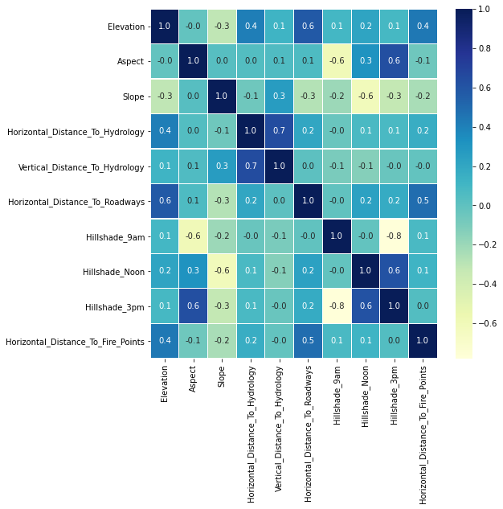

```python
f,ax = plt.subplots(figsize=(8,8))

sns.heatmap(df.iloc[:,0:10].corr(), annot = True, linewidths=0.1, fmt= '.1f',ax=ax, cmap="YlGnBu")

plt.show()
```

Nos "plus fortes" corrélations positives sont entre les variables :

- Vertical_Distance_To_Hydrology et Horizontal_Distance_To_Hydrology
- Horizontal_Distance_To_Roadways et Elevation
- Hillshade_3pm et Aspect
- Hillshade_3pm et Hillshade_Noon

Nos "plus fortes" correlations négatives sont entre les variables :

- Hillshade_9am et Aspect
- Hillshade_Noon et Slope
- Hillshade_3pm et Hillshade_9am

Puisque nous avons des corrélations négatives et positives dans ces premières colonnes, il n'y aura pas d'effet de taille pour une analyse de composantes principales.

## Visualisation des données

#### Visualisation des corrélations positives

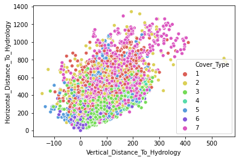

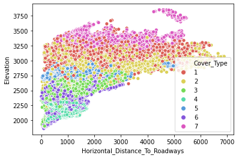

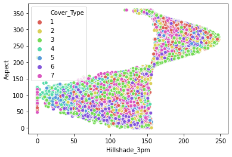

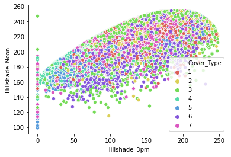

```python
list_x1 = ['Vertical_Distance_To_Hydrology', 'Horizontal_Distance_To_Roadways', 'Hillshade_3pm', 'Hillshade_3pm']
list_y1 = ['Horizontal_Distance_To_Hydrology', 'Elevation','Aspect', 'Hillshade_Noon']

for i in range(0,4):
    sns.scatterplot(list_x1[i], list_y1[i], hue = "Cover_Type", palette=sns.color_palette("hls", 7), data = df)
    plt.show()
```

Les corrélations entre les variables 'Aspect' et 'Hillshade_3pm', puis entre les variables 'Hillshade_Noon' et 'Hillshade_3pm' ont une forme particulière.

Quelques interprétations d'un point de vue visuel :

- Dans le premier graphique, nous pouvons voir que pour le couvert 7 (Krummholz), ce type d'arbre ne pousse vraiment lorsqu'il est proche d'une source d'eau. En revanche pour les types 3 (Ponderosa Pine) et 6 (Douglas-fir), nous avons besoin d'avoir une source d'eau proche pour qu'ils poussent
- Dans le deuxième graphique, nous pouvons distinguer plusieurs clusters selon l'élévation. Nous remarquons que peu importe la distance horizontale à la route la plus proche, seul le degré d'élévation va distinguer les différents types de couverts.

#### Visualisation des corrélations négatives

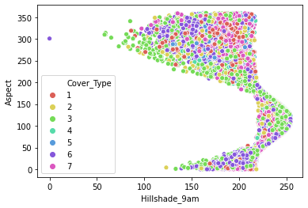

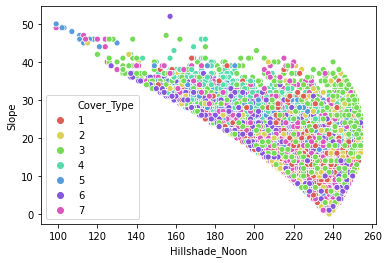

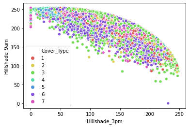

```python
list_x2 = ['Hillshade_9am', 'Hillshade_Noon', 'Hillshade_3pm']
list_y2 = ['Aspect', 'Slope','Hillshade_9am']

for i in range(0,3):
    sns.scatterplot(list_x2[i], list_y2[i], hue = "Cover_Type", palette=sns.color_palette("hls", 7), data = df)
    plt.show()
```

Les trois corrélations ont une forme particulière.

#### Histogrammes de nos variables quantitatives

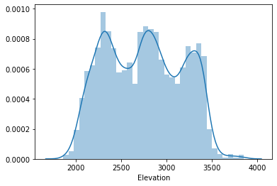

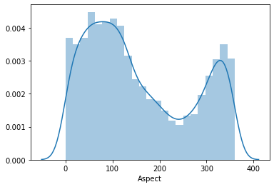

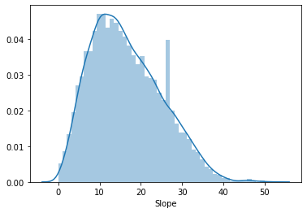

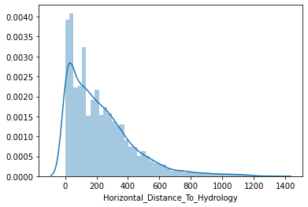

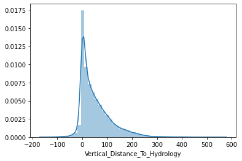

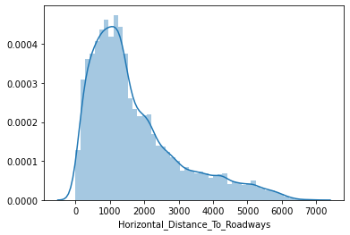

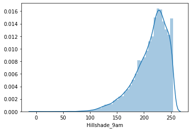

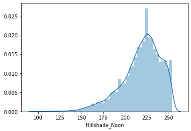

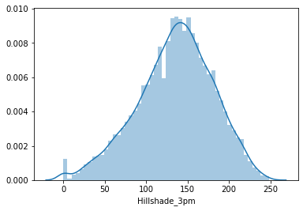

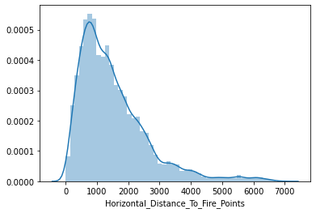

```python
for i in range(0,10):
    sns.distplot(df.iloc[:,i])
    plt.show()
```

Nous pouvons ici insister sur l'importance de la représentation visuelle des variables quantitatives. En effet, il n'est pas pertinent de se fier seulement aux coefficients d'asymétries (skewness) calculés précédemment pour étudier l'allure des distributions. Les histogrammes de l'Elevation et de l'Aspect contiennent différents "pics", informations non identifiables avec les coefficients d'asymétries.

#### Fréquence des zones sauvages selon les types de couverts forestiers

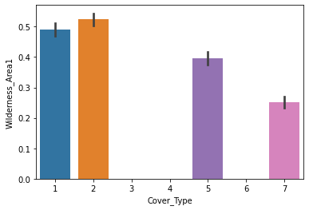

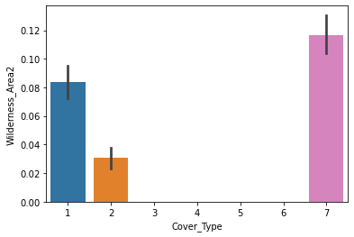

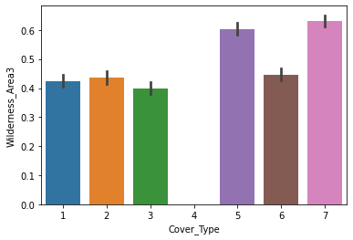

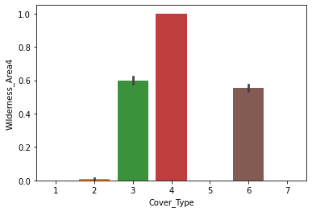

```python
for i in [1,2,3,4]:
    sns.barplot(x = "Cover_Type", y = "Wilderness_Area" + str(i), data = df)
    plt.show()
```

La distribution des zones sauvages par type de couverts forestiers n'est pas équilibrée. Des valeurs de types de couverts sont même manquantes la plupart du temps.

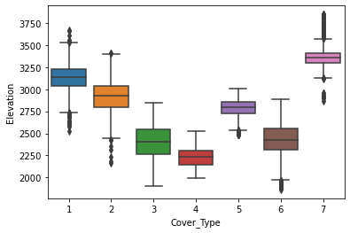

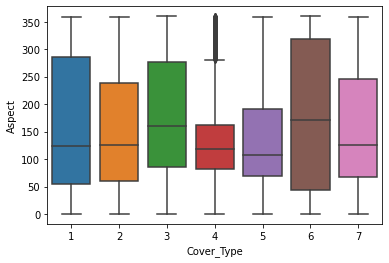

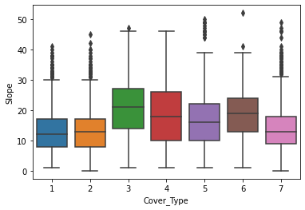

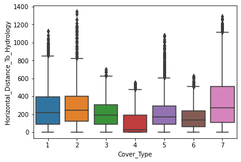

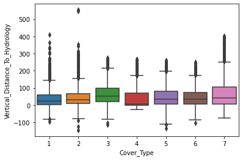

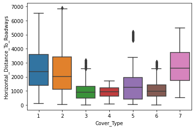

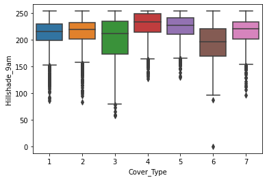

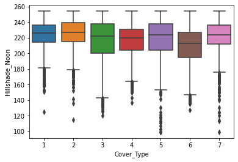

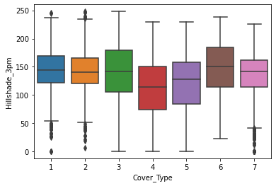

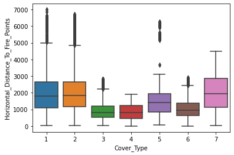

```python
for i in range(0,10):
    sns.boxplot(df.Cover_Type, df.iloc[:,i])
    plt.show()
```

A travers la visualisation de ces différents boxplots (visualisation de la distribution des valeurs selon les quantiles d'un attribut) sur nos variables quantitatives différenciés par les types de couverture forestière, nous obvervons que des valeurs aberrantes sont présentes dans notre jeu de donnée quantitatif. Ces valeurs seront à prendre en compte dans notre modélisation.

```python
df.describe()
```

|  | Elevation | Aspect | Slope | Horizontal_Distance_To_Hydrology | Vertical_Distance_To_Hydrology | Horizontal_Distance_To_Roadways | Hillshade_9am | Hillshade_Noon | Hillshade_3pm | Horizontal_Distance_To_Fire_Points | Wilderness_Area1 | Wilderness_Area2 | Wilderness_Area3 | Wilderness_Area4 | Soil_Type1 | Soil_Type2 | Soil_Type3 | Soil_Type4 | Soil_Type5 | Soil_Type6 | Soil_Type8 | Soil_Type9 | Soil_Type10 | Soil_Type11 | Soil_Type12 | Soil_Type13 | Soil_Type14 | Soil_Type16 | Soil_Type17 | … |
| --- | --- | --- | --- | --- | --- | --- | --- | --- | --- | --- | --- | --- | --- | --- | --- | --- | --- | --- | --- | --- | --- | --- | --- | --- | --- | --- | --- | --- | --- | --- |
| count | 15120.000000 | 15120.000000 | 15120.000000 | 15120.000000 | 15120.000000 | 15120.000000 | 15120.000000 | 15120.000000 | 15120.000000 | 15120.000000 | 15120.000000 | 15120.000000 | 15120.000000 | 15120.000000 | 15120.000000 | 15120.000000 | 15120.000000 | 15120.000000 | 15120.000000 | 15120.000000 | 15120.000000 | 15120.000000 | 15120.000000 | 15120.000000 | 15120.000000 | 15120.000000 | 15120.000000 | 15120.000000 | 15120.000000 | … |
| mean | 2749.322553 | 156.676653 | 16.501587 | 227.195701 | 51.076521 | 1714.023214 | 212.704299 | 218.965608 | 135.091997 | 1511.147288 | 0.237897 | 0.033003 | 0.419907 | 0.309193 | 0.023479 | 0.041204 | 0.063624 | 0.055754 | 0.010913 | 0.042989 | 0.000066 | 0.000661 | 0.141667 | 0.026852 | 0.015013 | 0.031481 | 0.011177 | 0.007540 | 0.040476 | … |
| std | 417.678187 | 110.085801 | 8.453927 | 210.075296 | 61.239406 | 1325.066358 | 30.561287 | 22.801966 | 45.895189 | 1099.936493 | 0.425810 | 0.178649 | 0.493560 | 0.462176 | 0.151424 | 0.198768 | 0.244091 | 0.229454 | 0.103896 | 0.202840 | 0.008133 | 0.025710 | 0.348719 | 0.161656 | 0.121609 | 0.174621 | 0.105133 | 0.086506 | 0.197080 | … |
| min | 1863.000000 | 0.000000 | 0.000000 | 0.000000 | -146.000000 | 0.000000 | 0.000000 | 99.000000 | 0.000000 | 0.000000 | 0.000000 | 0.000000 | 0.000000 | 0.000000 | 0.000000 | 0.000000 | 0.000000 | 0.000000 | 0.000000 | 0.000000 | 0.000000 | 0.000000 | 0.000000 | 0.000000 | 0.000000 | 0.000000 | 0.000000 | 0.000000 | 0.000000 | … |
| 25% | 2376.000000 | 65.000000 | 10.000000 | 67.000000 | 5.000000 | 764.000000 | 196.000000 | 207.000000 | 106.000000 | 730.000000 | 0.000000 | 0.000000 | 0.000000 | 0.000000 | 0.000000 | 0.000000 | 0.000000 | 0.000000 | 0.000000 | 0.000000 | 0.000000 | 0.000000 | 0.000000 | 0.000000 | 0.000000 | 0.000000 | 0.000000 | 0.000000 | 0.000000 | … |
| 50% | 2752.000000 | 126.000000 | 15.000000 | 180.000000 | 32.000000 | 1316.000000 | 220.000000 | 223.000000 | 138.000000 | 1256.000000 | 0.000000 | 0.000000 | 0.000000 | 0.000000 | 0.000000 | 0.000000 | 0.000000 | 0.000000 | 0.000000 | 0.000000 | 0.000000 | 0.000000 | 0.000000 | 0.000000 | 0.000000 | 0.000000 | 0.000000 | 0.000000 | 0.000000 | … |
| 75% | 3104.000000 | 261.000000 | 22.000000 | 330.000000 | 79.000000 | 2270.000000 | 235.000000 | 235.000000 | 167.000000 | 1988.250000 | 0.000000 | 0.000000 | 1.000000 | 1.000000 | 0.000000 | 0.000000 | 0.000000 | 0.000000 | 0.000000 | 0.000000 | 0.000000 | 0.000000 | 0.000000 | 0.000000 | 0.000000 | 0.000000 | 0.000000 | 0.000000 | 0.000000 | … |
| max | 3849.000000 | 360.000000 | 52.000000 | 1343.000000 | 554.000000 | 6890.000000 | 254.000000 | 254.000000 | 248.000000 | 6993.000000 | 1.000000 | 1.000000 | 1.000000 | 1.000000 | 1.000000 | 1.000000 | 1.000000 | 1.000000 | 1.000000 | 1.000000 | 1.000000 | 1.000000 | 1.000000 | 1.000000 | 1.000000 | 1.000000 | 1.000000 | 1.000000 | 1.000000 | … |

## Modélisation

```python
from sklearn.model_selection import train_test_split
from sklearn import metrics
```

```python
import sklearn.datasets as sk_d
import sklearn.model_selection as sk_ms
import sklearn.ensemble as sk_e
import sklearn.svm as sk_s
import sklearn.linear_model as sk_lm
import sklearn.preprocessing as sk_p
import sklearn.metrics as sk_m
import sklearn.decomposition as sk_de
import sklearn.cluster as sk_c
import warnings
warnings.filterwarnings('ignore')
```

#### Normalisation des données

```python
scaler = sk_p.MinMaxScaler()
X_norm = scaler.fit_transform(df.iloc[:,0:10])
X_norm = pd.DataFrame(X_norm, columns = df.columns[0:10], index = df.index)
X_norm
```

|  | Elevation | Aspect | Slope | Horizontal_Distance_To_Hydrology | Vertical_Distance_To_Hydrology | Horizontal_Distance_To_Roadways | Hillshade_9am | Hillshade_Noon | Hillshade_3pm | Horizontal_Distance_To_Fire_Points |
| --- | --- | --- | --- | --- | --- | --- | --- | --- | --- | --- |
| 0 | 0.369084 | 0.141667 | 0.057692 | 0.192107 | 0.208571 | 0.074020 | 0.870079 | 0.858065 | 0.596774 | 0.897898 |
| 1 | 0.366062 | 0.155556 | 0.038462 | 0.157856 | 0.200000 | 0.056604 | 0.866142 | 0.877419 | 0.608871 | 0.890176 |
| 2 | 0.473817 | 0.386111 | 0.173077 | 0.199553 | 0.301429 | 0.461538 | 0.921260 | 0.896774 | 0.544355 | 0.875304 |
| 3 | 0.464250 | 0.430556 | 0.346154 | 0.180194 | 0.377143 | 0.448476 | 0.937008 | 0.896774 | 0.491935 | 0.888174 |
| 4 | 0.368580 | 0.125000 | 0.038462 | 0.113924 | 0.207143 | 0.056749 | 0.866142 | 0.870968 | 0.604839 | 0.882597 |
| ... | ... | ... | ... | ... | ... | ... | ... | ... | ... | ... |
| 15115 | 0.374622 | 0.675000 | 0.442308 | 0.192107 | 0.218571 | 0.095791 | 0.669291 | 0.980645 | 0.862903 | 0.183326 |
| 15116 | 0.372608 | 0.336111 | 0.365385 | 0.471333 | 0.487143 | 0.089695 | 0.980315 | 0.787097 | 0.366935 | 0.189475 |
| 15117 | 0.316717 | 0.372222 | 0.480769 | 0.271780 | 0.375714 | 0.048621 | 0.984252 | 0.780645 | 0.334677 | 0.169741 |
| 15118 | 0.314199 | 0.463889 | 0.538462 | 0.162323 | 0.352857 | 0.035123 | 0.901575 | 0.890323 | 0.479839 | 0.133276 |
| 15119 | 0.308157 | 0.547222 | 0.653846 | 0.237528 | 0.320000 | 0.039187 | 0.744094 | 0.935484 | 0.661290 | 0.130702 |

15120 rows × 10 columns

Nous souhaitons d'abord normaliser nos données quantitatives continues, au cas où certains modèles que nous allons utiliser seraient sensibles à la variance du dataset. Ce X_norm servira uniquement pour l'analyse en composantes principales (puisque les variables catégorielles vont biaiser l'ACP).

```python
scaler = sk_p.MinMaxScaler()
X_norm = scaler.fit_transform(df.iloc[:,0:10])
X_norm = pd.DataFrame(X_norm, columns = df.columns[0:10], index = df.index)
X_norm_1 = pd.merge(X_norm,df.iloc[:,11:],how='left',left_index=True,right_index=True)
X_norm_1
```

|  | Elevation | Aspect | Slope | Horizontal_Distance_To_Hydrology | Vertical_Distance_To_Hydrology | Horizontal_Distance_To_Roadways | Hillshade_9am | Hillshade_Noon | Hillshade_3pm | Horizontal_Distance_To_Fire_Points | Wilderness_Area2 | Wilderness_Area3 | Wilderness_Area4 | Soil_Type1 | Soil_Type2 | Soil_Type3 | Soil_Type4 | Soil_Type5 | Soil_Type6 | Soil_Type8 | Soil_Type9 | Soil_Type10 | Soil_Type11 | Soil_Type12 | Soil_Type13 | Soil_Type14 | Soil_Type16 | Soil_Type17 | Soil_Type18 | … |
| --- | --- | --- | --- | --- | --- | --- | --- | --- | --- | --- | --- | --- | --- | --- | --- | --- | --- | --- | --- | --- | --- | --- | --- | --- | --- | --- | --- | --- | --- | --- |
| 0 | 0.369084 | 0.141667 | 0.057692 | 0.192107 | 0.208571 | 0.074020 | 0.870079 | 0.858065 | 0.596774 | 0.897898 | 0 | 0 | 0 | 0 | 0 | 0 | 0 | 0 | 0 | 0 | 0 | 0 | 0 | 0 | 0 | 0 | 0 | 0 | 0 | … |
| 1 | 0.366062 | 0.155556 | 0.038462 | 0.157856 | 0.200000 | 0.056604 | 0.866142 | 0.877419 | 0.608871 | 0.890176 | 0 | 0 | 0 | 0 | 0 | 0 | 0 | 0 | 0 | 0 | 0 | 0 | 0 | 0 | 0 | 0 | 0 | 0 | 0 | … |
| 2 | 0.473817 | 0.386111 | 0.173077 | 0.199553 | 0.301429 | 0.461538 | 0.921260 | 0.896774 | 0.544355 | 0.875304 | 0 | 0 | 0 | 0 | 0 | 0 | 0 | 0 | 0 | 0 | 0 | 0 | 0 | 1 | 0 | 0 | 0 | 0 | 0 | … |
| 3 | 0.464250 | 0.430556 | 0.346154 | 0.180194 | 0.377143 | 0.448476 | 0.937008 | 0.896774 | 0.491935 | 0.888174 | 0 | 0 | 0 | 0 | 0 | 0 | 0 | 0 | 0 | 0 | 0 | 0 | 0 | 0 | 0 | 0 | 0 | 0 | 0 | … |
| 4 | 0.368580 | 0.125000 | 0.038462 | 0.113924 | 0.207143 | 0.056749 | 0.866142 | 0.870968 | 0.604839 | 0.882597 | 0 | 0 | 0 | 0 | 0 | 0 | 0 | 0 | 0 | 0 | 0 | 0 | 0 | 0 | 0 | 0 | 0 | 0 | 0 | … |
| ... | ... | ... | ... | ... | ... | ... | ... | ... | ... | ... | ... | ... | ... | ... | ... | ... | ... | ... | ... | ... | ... | ... | ... | ... | ... | ... | ... | ... | ... | … |
| 15115 | 0.374622 | 0.675000 | 0.442308 | 0.192107 | 0.218571 | 0.095791 | 0.669291 | 0.980645 | 0.862903 | 0.183326 | 0 | 1 | 0 | 0 | 0 | 0 | 1 | 0 | 0 | 0 | 0 | 0 | 0 | 0 | 0 | 0 | 0 | 0 | 0 | … |
| 15116 | 0.372608 | 0.336111 | 0.365385 | 0.471333 | 0.487143 | 0.089695 | 0.980315 | 0.787097 | 0.366935 | 0.189475 | 0 | 1 | 0 | 0 | 0 | 0 | 1 | 0 | 0 | 0 | 0 | 0 | 0 | 0 | 0 | 0 | 0 | 0 | 0 | … |
| 15117 | 0.316717 | 0.372222 | 0.480769 | 0.271780 | 0.375714 | 0.048621 | 0.984252 | 0.780645 | 0.334677 | 0.169741 | 0 | 1 | 0 | 0 | 0 | 0 | 1 | 0 | 0 | 0 | 0 | 0 | 0 | 0 | 0 | 0 | 0 | 0 | 0 | … |
| 15118 | 0.314199 | 0.463889 | 0.538462 | 0.162323 | 0.352857 | 0.035123 | 0.901575 | 0.890323 | 0.479839 | 0.133276 | 0 | 1 | 0 | 0 | 0 | 0 | 1 | 0 | 0 | 0 | 0 | 0 | 0 | 0 | 0 | 0 | 0 | 0 | 0 | … |
| 15119 | 0.308157 | 0.547222 | 0.653846 | 0.237528 | 0.320000 | 0.039187 | 0.744094 | 0.935484 | 0.661290 | 0.130702 | 0 | 1 | 0 | 0 | 1 | 0 | 0 | 0 | 0 | 0 | 0 | 0 | 0 | 0 | 0 | 0 | 0 | 0 | 0 | … |

15120 rows × 52 columns

Concaténation des données normalisées avec les données catégorielles pour la modélisation.